# DATASCI 151 - Introduction to Statistical Computing II

Lecture 01 - Introduction and Course Overview

Danilo Freire

danilo.freire@emory.edu

Department of Data and Decision Sciences  
Emory University

# Welcome to DATASCI 151! 🥳

## Lecture overview

- Introduction: Hello everyone! 🙋🏻
- Motivation: Why learn Python and SQL?
- Class Logistics: Course objectives, grading, and late policy
- Computing Set up: Anaconda, Jupyter, VS Code

[figure not shown]

## Course materials

### Important links

Course website: https://danilofreire.github.io/datasci151-summer

Course repository: https://github.com/danilofreire/datasci151-summer

- This course is hosted on [GitHub](https://github.com), where you will find the syllabus, lecture materials, and assignments. The tutorials are on the [course website](https://danilofreire.github.io/datasci151-summer/tutorials.html). You can download the materials and follow along with the lectures using Jupyter Notebooks or the lecture notes
- Canvas will be used for course management, including assignment submissions, grades, and announcements. Please familiarise yourself with both platforms, and reach out if you have any questions

**Note**

Please remember to check the course website regularly for updates and announcements 😉

# Nice to meet you! 👋

## Instructor

### A bit about me

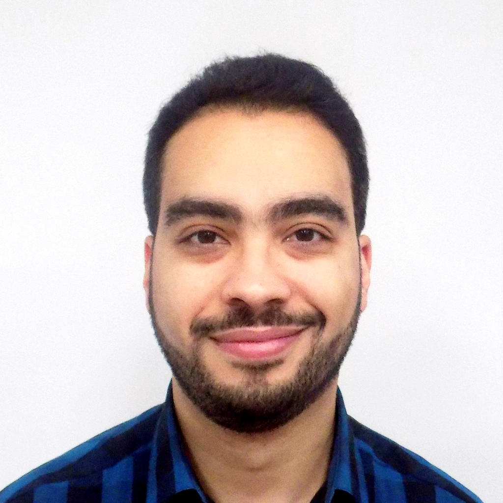

danilo.freire@emory.edu

https://danilofreire.github.io/

Visiting Assistant Professor in the [Department of Data and Decision Sciences](https://datascience.emory.edu/index.html)

MA from the Graduate Institute Geneva, PhD from King’s College London, Postdoc at Brown University, Senior Lecturer at the University of Lincoln, UK

Research interests: computational social science, experimental methods, policy evaluation, political violence, organised crime

I also teach [DATASCI 101 - Introduction to AI Applications](https://danilofreire.github.io/datasci101), [DATASCI 350 - Data Science Computing](https://danilofreire.github.io/datasci350), and [DATASCI 385 - Experimental Methods](https://danilofreire.github.io/datasci385)

## My teaching philosophy

### What you can expect from me

- I love teaching and aim to make learning fun! 😄
- Classes where students participate are the best
- Hands-on activities help you learn better
- I am always available to help and answer questions. And I mean it!
- Feel free to ask questions during class, office hours, or via email 😉

## Office hours: what for and what not for

- What office hours are meant for:
  - Applying tools in practice
  - Discussion of issues related to the assignments
  - Boosting your knowledge of data science
- What these sessions are not meant for:
  - Solving the assignments for you
  - Taking care of developing your coding skills

## Class etiquette

- Coding can be tough and push you out of your comfort zone. If the course pace is too fast, let me know. I expect your commitment, but I do not want anyone to fail
- You are all keen on data science, but your backgrounds vary. That is great! Some sessions might be more engaging than others. If you are bored, help others or explore new data science areas
- Always be respectful to each other
- Ask questions whenever you need to!

[figure not shown]

# Why Python and SQL? 🐍🗄️

## Why Python

### The world’s most popular programming language

[figure not shown]

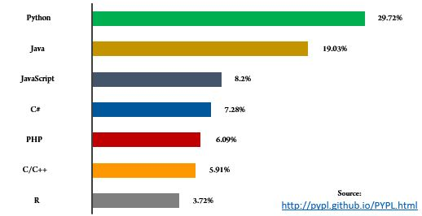

## Why Python

### Great community and easy to learn

There are thousands of Python user groups worldwide

The Python community is very active and welcoming!

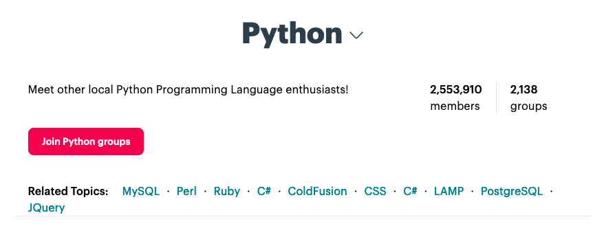

- Java:

```
public class Welcome {
    public static void main(String[] args) {
        System.out.println("Welcome to DATASCI 151!");
    }
}
```

- Python:

```python
print("Welcome to DATASCI 151!")
```

Much easier! 😃

## Why Python

### Salaries are good!

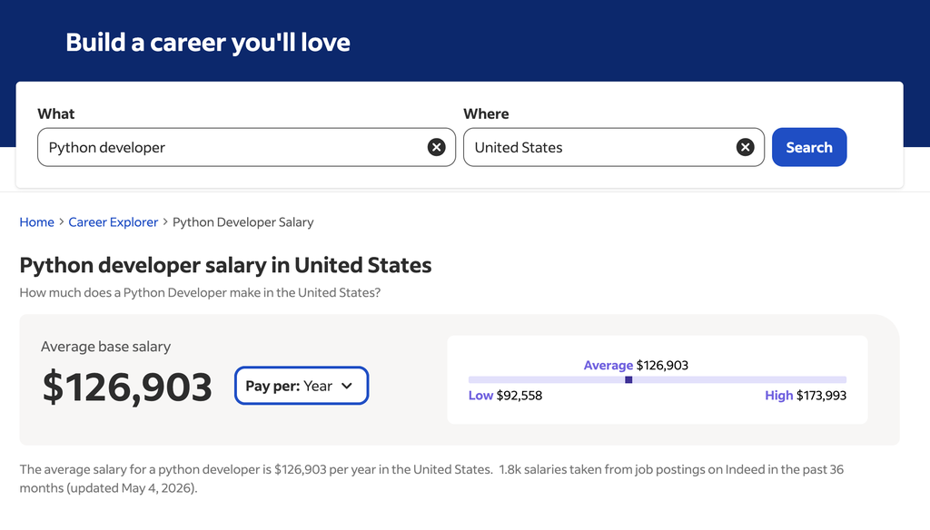

## Why SQL

### The world’s most popular database language

- SQL is the standard language for relational database management systems
- Easy to learn
- Standardised
- Manage huge amounts of data
- Widely used in industry
- Great for data analysis

[figure not shown]

[figure not shown]

## Why SQL

### Salaries are good too!

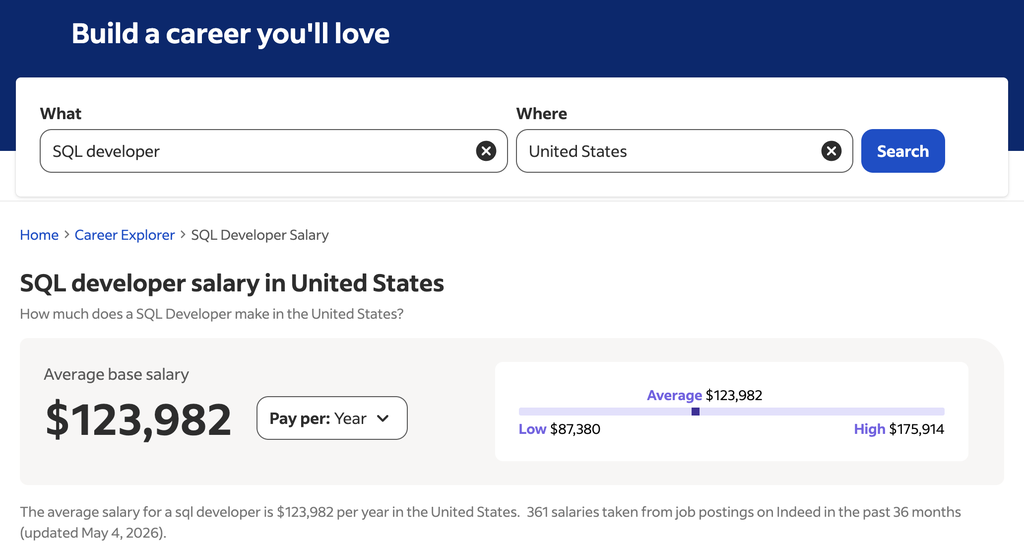

# Course logistics 📚

## Course objectives

1. Perform basic operations and write functions in Python
2. Use Jupyter Notebooks for reproducible research
3. Conduct data wrangling and manipulate data using Python libraries such as Pandas
4. Create visualisations to effectively communicate data insights
5. Merge and manage databases using SQL
6. Develop problem-solving skills relevant to data analysis and statistical computing

## Grades and late policy

- Assignments (x5): 50%
  - Practice class concepts
  - AI tools are allowed to support your own thinking
- Quizzes (x3): 50%
  - Questions are based on the lecture notes and assignments
  - Quizzes are open-book and open-notes (including the internet)
  - AI tools are not allowed during quizzes
- All materials are available on the course website and GitHub repository
- Late assignments will automatically be graded for half-credit
- Follow the [tutorials on the course website](https://danilofreire.github.io/datasci151-summer/tutorials.html) to install the software. You will need it to use the lecture notes

# Computing set up 🖥️

## Our class in a nutshell

[figure not shown]

## Installing Python using Anaconda

### Anaconda has all the libraries we need

- Follow the instructions [on our GitHub website](https://danilofreire.github.io/datasci151-summer/01-vscode-anaconda-tutorial.html)
- Or just go to https://www.anaconda.com/download/success?reg=skipped and download the version for your operating system
- We will use Anaconda’s default environment, called `base` (more on environments next class)
- For now: Anaconda comes with a full Python installation with everything you need to follow along with the course
- Questions?

## Installing VS Code and connecting Anaconda

### Let’s do it together!

Install VS Code

- Follow our [step-by-step tutorial](https://danilofreire.github.io/datasci151-summer/01-vscode-anaconda-tutorial.html) on our website
- Or download VS Code directly at https://code.visualstudio.com/download (Windows, Mac, or Linux)
- Find the Extensions icon in the left sidebar (four small squares with one offset), or press `Ctrl+Shift+X` (`Cmd+Shift+X` on Mac)
- Install the [Jupyter](https://marketplace.visualstudio.com/items?itemName=ms-toolsai.jupyter) and [Python](https://marketplace.visualstudio.com/items?itemName=ms-python.python) extensions for VS Code

Connect to Anaconda

- In VS Code, open “View” → “Command Palette”
- Type “Python: Select Interpreter” and pick your Anaconda environment
- Use “base” (Anaconda’s default environment) for this course

# Git and GitHub 🐙

## Git and GitHub

- [Git](https://git-scm.com/) is a [version control system](https://en.wikipedia.org/wiki/Version_control) for tracking code changes and collaborating with others
- Think Google Docs plus Microsoft Word’s track changes, but for code (and far more powerful!)
- [GitHub](https://github.com/) is a web platform built on Git for sharing code and collaborating on projects
- It is also a social network for developers: follow others, star projects, contribute to open source
- Get a free student account: https://github.com/education/students

[figure not shown]

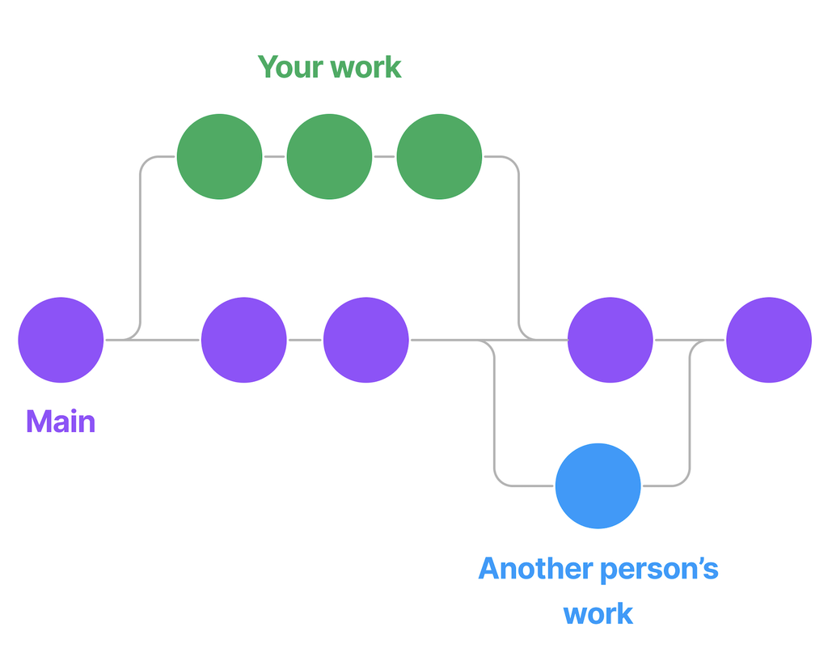

## How to download the course materials

- Go to the course repository: https://github.com/danilofreire/datasci151-summer
- Click on the green “Code” button and then “Download ZIP”
- Unzip the file and open the folder in VS Code
- You can add the folder to your VS Code workspace for easy access to the materials
  - In VS Code, click on “File” and then “Add Folder to Workspace”
  - Select the folder you just downloaded and click “Add”

[figure not shown]

https://github.com/danilofreire/datasci151-summer

# Jupyter Notebooks 📘

## Jupyter Notebooks

- [Jupyter Notebooks](https://jupyter.org/) are a great way to combine code, text, and visualisations!
- If you have used [R Markdown](https://rmarkdown.rstudio.com/), you will find Jupyter Notebooks very similar
- They are widely used in data science and machine learning, and are a great way to share your work with others
- Please install the [Jupyter extension](https://marketplace.visualstudio.com/items?itemName=ms-toolsai.jupyter) for VS Code

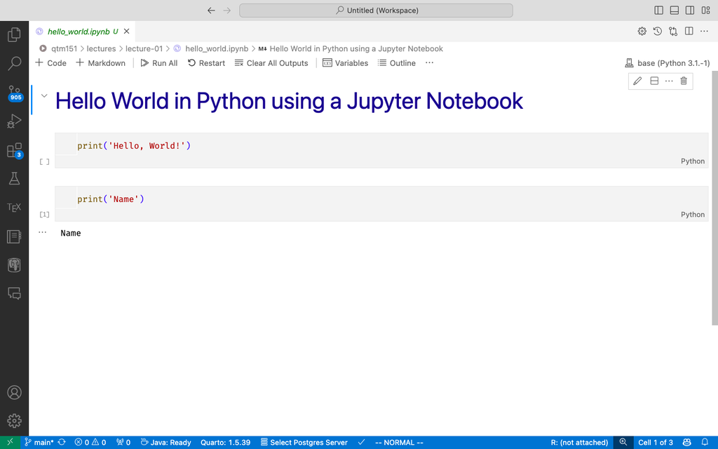

- If you are using Anaconda, Jupyter Notebooks should be installed by default. If not, you can install it using the Anaconda Navigator or the command line

```
conda install jupyter
```

## Jupyter Notebooks

- We will use Jupyter Notebooks a lot for our classes!
- Quizzes and assignments will be in this format
- Our website has [a tutorial on how to use them too](https://danilofreire.github.io/datasci151-summer/02-jupyter-markdown-tutorial.html)
- There are both Jupyter Notebooks and lecture notes for each class in the course repository
- So you can choose which one you prefer to use, or use both!
- Lecture notes are designed to be followed along, and there will be many “try it yourself” exercises throughout the lectures!
- In case you have any trouble with the installation, you can also use an online version of Jupyter Notebooks included in our website: https://danilofreire.github.io/datasci151-summer/
- Just click on “Jupyter Lite” and it will open a Jupyter Notebook in your browser

[figure not shown]

## Next class

- Let me know if you have any questions about the course or the material or how to set up your computer
- We will install packages and create our first notebook
- We will also work with variables and lists
- Please remember to check the course repository and the website at https://github.com/danilofreire/datasci151-summer and https://danilofreire.github.io/datasci151-summer
- And please do not forget:
  - Coding ability can be developed
  - Academic skills and abilities are acquired through hard work, mistakes, and perseverance. Coding is no different
  - My only goal here is that you learn the material. Please ask me questions! 😉

# Questions?

# Thank you very much for your attention! 🙏🎉